# Multilevel tutorial 1, part II

### Setup

```r
# Load packages
require(ggplot2)
# Source the inv.logit and logit functions for ease of use.
source('http://pastebin.com/raw.php?i=v1PDDYz7')
setwd('D:/files/teaching/2014multilevel/')
```

## Question 1

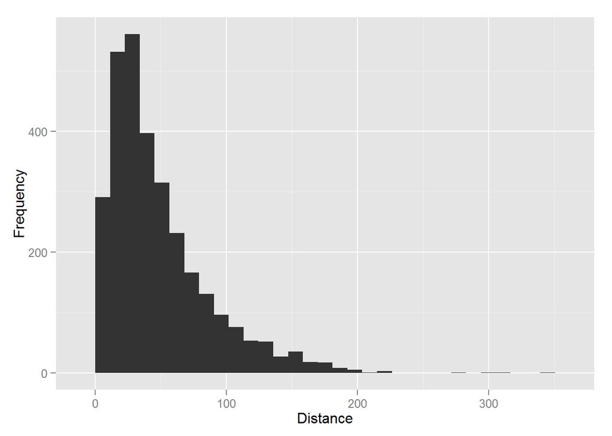

```r
wells <- read.table('1_wells.dat')
qplot(dist, data=wells, xlab="Distance", ylab="Frequency")
```

## Question 2

```r
M1 <- glm(switch ~ 1 + dist, data=wells, family=binomial(link="logit"))
print(M1)
```

```
##
## Call:  glm(formula = switch ~ 1 + dist, family = binomial(link = "logit"),
##     data = wells)
##
## Coefficients:
## (Intercept)         dist
##    0.605959    -0.006219
##
## Degrees of Freedom: 3019 Total (i.e. Null);  3018 Residual
## Null Deviance:       4118
## Residual Deviance: 4076  AIC: 4080
```

## Question 3

```r
wells$dist100 <- wells$dist / 100
M2 <- glm(switch ~ 1 + dist100, data=wells, family=binomial(link="logit"))
print(M2)
```

```
##
## Call:  glm(formula = switch ~ 1 + dist100, family = binomial(link = "logit"),
##     data = wells)
##
## Coefficients:
## (Intercept)      dist100
##      0.6060      -0.6219
##
## Degrees of Freedom: 3019 Total (i.e. Null);  3018 Residual
## Null Deviance:       4118
## Residual Deviance: 4076  AIC: 4080
```

The model has the exact same model fit, only the coefficient of the predictor distance changes by two decimal places; .0062 becomes .62).

## Question 4

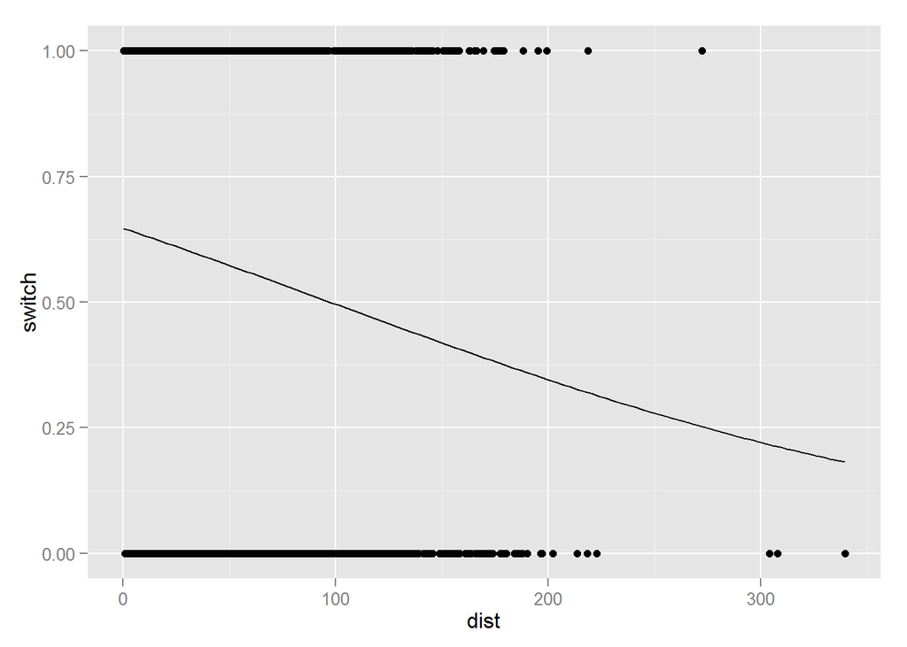

```r
ggplot(wells, aes(dist, switch)) + geom_point() + stat_function(fun=function(X) inv.logit(coef(M1)[1]+coef(M1)[2]*X))
```

## Question 5

```
## stat_bin: binwidth defaulted to range/30. Use 'binwidth = x' to adjust this.
```

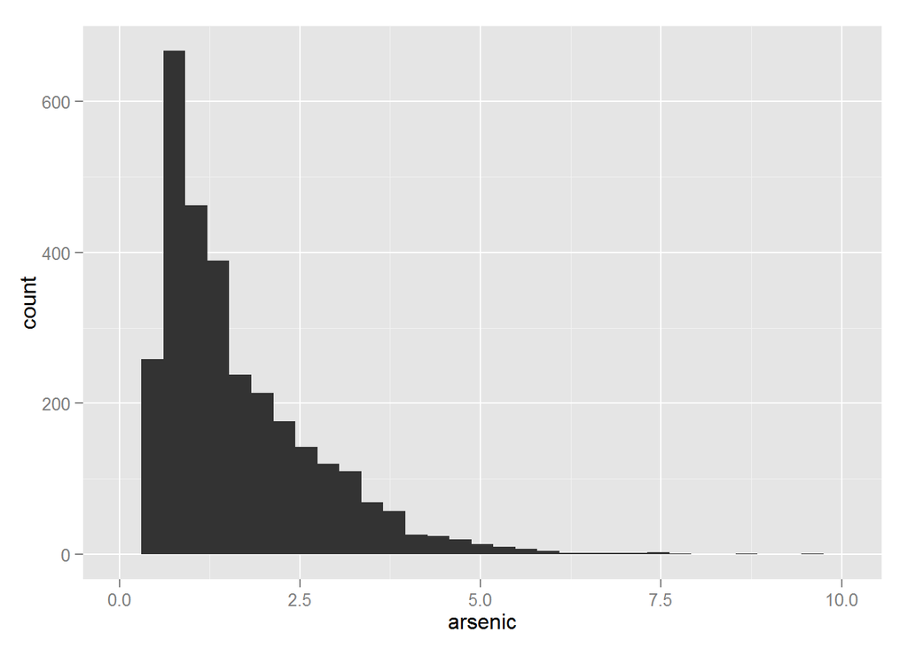

```r
qplot(arsenic, data=wells)
```

```r
M3 <- glm(switch ~ 1 + dist100 + arsenic, data=wells, family=binomial(link="logit"))
print(anova(M2, M3, test="Chisq"))
```

```
## Analysis of Deviance Table
##
## Model 1: switch ~ 1 + dist100
## Model 2: switch ~ 1 + dist100 + arsenic
##   Resid. Df Resid. Dev Df Deviance  Pr(>Chi)
## 1      3018     4076.2
## 2      3017     3930.7  1   145.57 < 2.2e-16 ***
## ---
## Signif. codes:  0 '***' 0.001 '**' 0.01 '*' 0.05 '.' 0.1 ' ' 1
```

I would choose M3, because the model fit is significantly better, $\chi^{2}$ = 145.5695576, p = 1.6122910^{-33}, indicating the reduction of unexplained variance is more than would be expected if arsenic would not be able to explain the switching of wells at the population level.

## Question 6

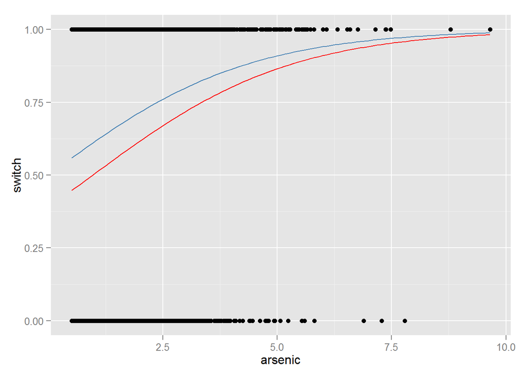

```r
ggplot(wells, aes(arsenic, switch)) + geom_point() + stat_function(fun=function(x) inv.logit(coef(M3)[1]+coef(M3)[2]*0+coef(M3)[3]*x), col="steelblue") + stat_function(fun=function(x) inv.logit(coef(M3)[1]+coef(M3)[2]*.5+coef(M3)[3]*x), col="red")
```

## Question 7

```r
M4 <- glm(switch ~ 1 + dist100 + arsenic + arsenic*dist100, data=wells, family=binomial(link="logit"))
print(anova(M3, M4, test="Chisq"))
```

```
## Analysis of Deviance Table
##
## Model 1: switch ~ 1 + dist100 + arsenic
## Model 2: switch ~ 1 + dist100 + arsenic + arsenic * dist100
##   Resid. Df Resid. Dev Df Deviance Pr(>Chi)
## 1      3017     3930.7
## 2      3016     3927.6  1   3.0399  0.08124 .
## ---
## Signif. codes:  0 '***' 0.001 '**' 0.01 '*' 0.05 '.' 0.1 ' ' 1
```

Model 4 does not significantly reduce the unexplained variance, $^{2}=$3.039865, p = 0.0812427. Hence, not enough evidence is present for an interaction effect in the population.

## Question 8

```r
wells$dist100centred <- wells$dist100 - mean(wells$dist100)
wells$arscentred <- wells$arsenic - mean(wells$arsenic)
M4 <- glm(switch ~ 1 + dist100centred + arscentred + arscentred*dist100centred, data=wells, family=binomial(link="logit"))
```

The mean respondent in the dataset has a probability of 0.5868829 to switch. There are significant main effects of distance (b=-0.8736527, p =7.644549410^{-17}) and arsenic (b=0.4695081, p=6.455719210^{-29}) on the probability to switch, but not enough evidence for an interaction effect (b=-0.178906, p = 0.0804026).

## Question 9

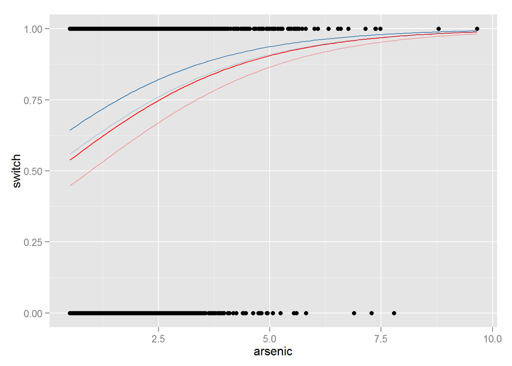

```r
ggplot(wells, aes(arsenic, switch)) +
  geom_point() +
  stat_function(fun=function(x) inv.logit(coef(M4)[1]+coef(M4)[2]*0+coef(M4)[3]*x), col="steelblue") +
  stat_function(fun=function(x) inv.logit(coef(M4)[1]+coef(M4)[2]*.5+coef(M4)[3]*x), col="red") +
  stat_function(fun=function(x) inv.logit(coef(M3)[1]+coef(M3)[2]*0+coef(M3)[3]*x), col="steelblue", alpha=.3) +
  stat_function(fun=function(x) inv.logit(coef(M3)[1]+coef(M3)[2]*.5+coef(M3)[3]*x), col="red", alpha=.3)
```

The transparent lines are from M3, whereas the solid lines are from M4. Hence, we see the models differ somewhat, but not by much. The statistical results indicate there is no evidence to conclude that M4 works systematically better.